# Time series of Environmental Sensors: basic analysis

J-AIL course: Introduction to Time Series Analysis in Limnology

Lluís Gómez Gener[^1]

31/3/2022

# Introduction

In this session we will learn how to use basic functions to analyze “environmental sensor” time series.

Before we start any time series analysis in R, a key decision is your choice of data representation (object class). This is especially critical in an object-oriented language such as R, because the choice affects more than how the data is stored; it also dictates which functions (methods) will be available for loading, processing, analyzing, printing, and plotting your data. When many people start using R they simply store time series data in vectors(as we mostly have done in the previous sessions). That seems natural. However, they quickly discover that none of the coolest analytics for time series analysis work with simple vectors. We’ve found when users switch to using an object class intended for time series data, the analysis gets easier, opening a gateway to valuable functions and analytics.

Most of the functions used in this session (or R Markdown file) require the time series to be in the `ts` object class.

# Resources

- Dettling, M. *Time Series Analysis: ETH Course* [Website](https://www.dropbox.com/s/m4ryp8qcchoukg4/Time%20Series%20Analysis_ETH_COURSE.pdf?dl=0).
- Coghlan, a. *A Little Book of R For Time Series* [Website](https://buildmedia.readthedocs.org/media/pdf/a-little-book-of-r-for-time-series/latest/a-little-book-of-r-for-time-series.pdf).

# A. Workflow for sensor TS basic analysis

## 1. Importing and visualizing a TS class object

Before starting, we need to load some packages:

```r
library(tidyverse)
```

We also need to set up the working directory (i.e., folder where where R will find the files or/and store the outputs). This path MUST correspond to the path where your data is stored:

```r
setwd("C:/Users/lgomez/Dropbox/Teaching and research GENERAL/00_Teaching general/Introduction to time series analysis (JAIL)")
getwd()
```

```
## [1] "C:/Users/lgomez/Dropbox/Teaching and research GENERAL/00_Teaching general/Introduction to time series analysis (JAIL)"
```

Now we are are ready to read the .csv files, for this we will use the function `read_csv()`, which is part of the core `tidyverse`.

```r
snow <- read_csv('00_course datasets/snow_pyrenees_2.csv')
```

Let’s see how to transform our data frame to a ts object class.

```r
snow.ts <- ts(snow, frequency=365, start=c(2001,1))
head(snow.ts)
```

```
##      snow_area_km2
## [1,]         13366
## [2,]         12286
## [3,]         11620
## [4,]         12718
## [5,]         12594
## [6,]         12694
```

```r
tail(snow.ts)
```

```
##      snow_area_km2
## [1,]        4712.5
## [2,]        4691.0
## [3,]        4761.8
## [4,]        5073.5
## [5,]        4755.2
## [6,]        4922.8
```

Let’s vsualize our TS:

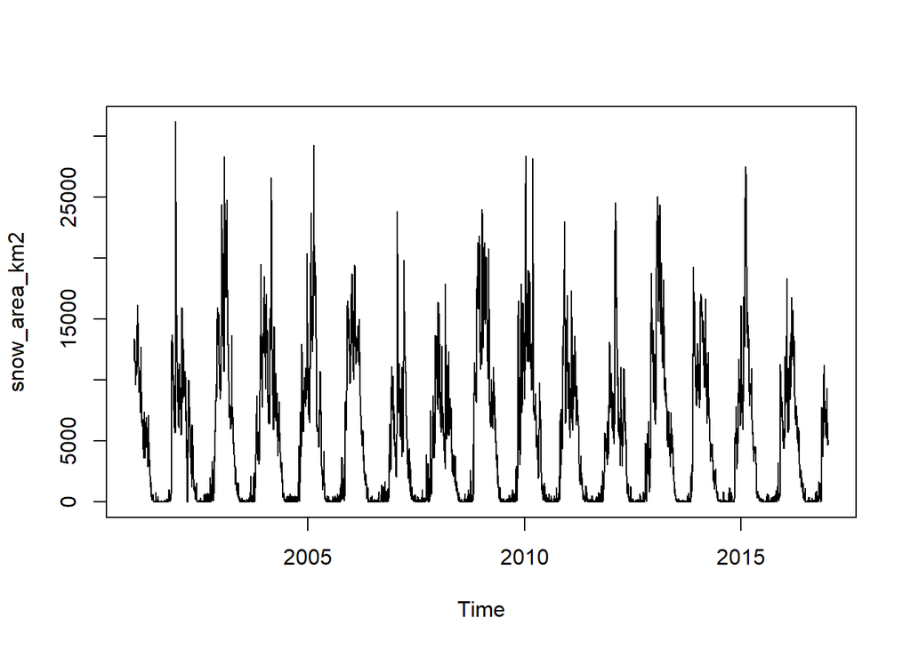

```r
plot(snow.ts)
```

## 2. Decomposing a TS

To estimate the trend component and seasonal component of a seasonal time series that can be described using an additive model, we can use the “decompose()” function in R. This function estimates the trend, seasonal, and irregular components of a time series that can be described using an additive model.

```r
snow.ts.components <- decompose(snow.ts)
head(snow.ts.components$seasonal)
```

```
## [1] 5288.873 5233.813 5486.874 5374.296 6158.009 5898.657
```

We can plot the estimated trend, seasonal, and irregular components of the time series by using the “plot()” function, for example:

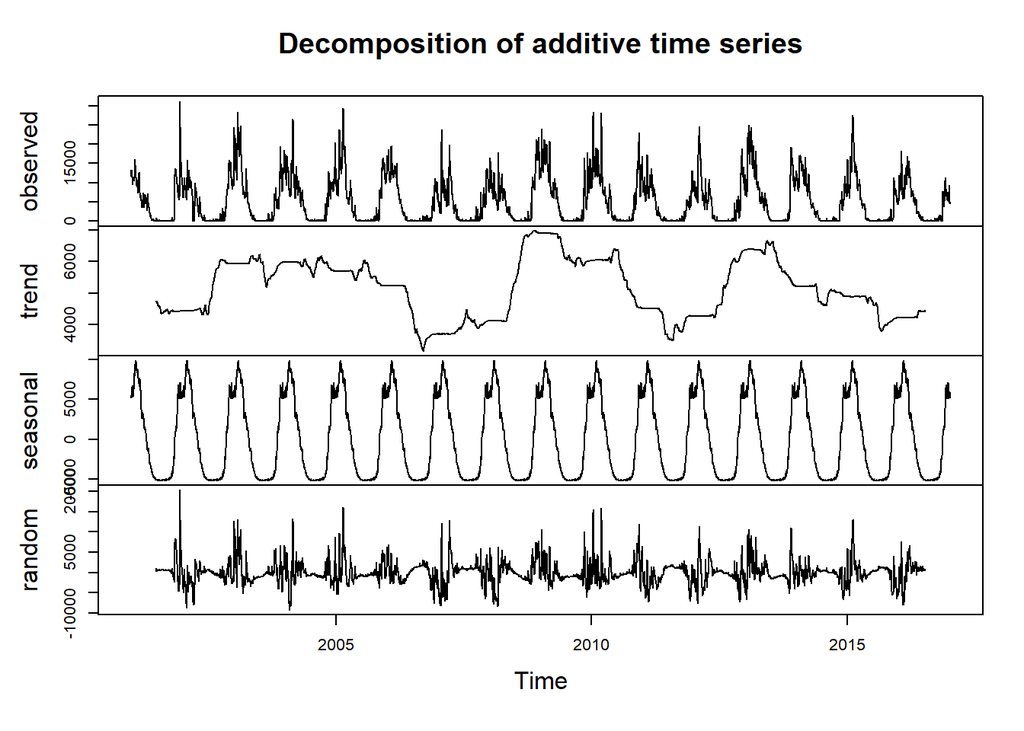

```r
plot(snow.ts.components)
```

## 3. Differencing

### 3.1. Removing the trend by differencing

A simple approach for removing deterministic trends and/or seasonal effects from a time series is by taking differences (i.e. a way to make a non-stationary time series stationar). A practical interpretation of taking differences is that by doing so, the changes in the data will be monitored, but no longer the series itself.

We illustrate how differencing works by using a dataset that shows the number of mountain rescues in the Vall d’Aran for the period 1990-2010. We type in the values and plot the original series:

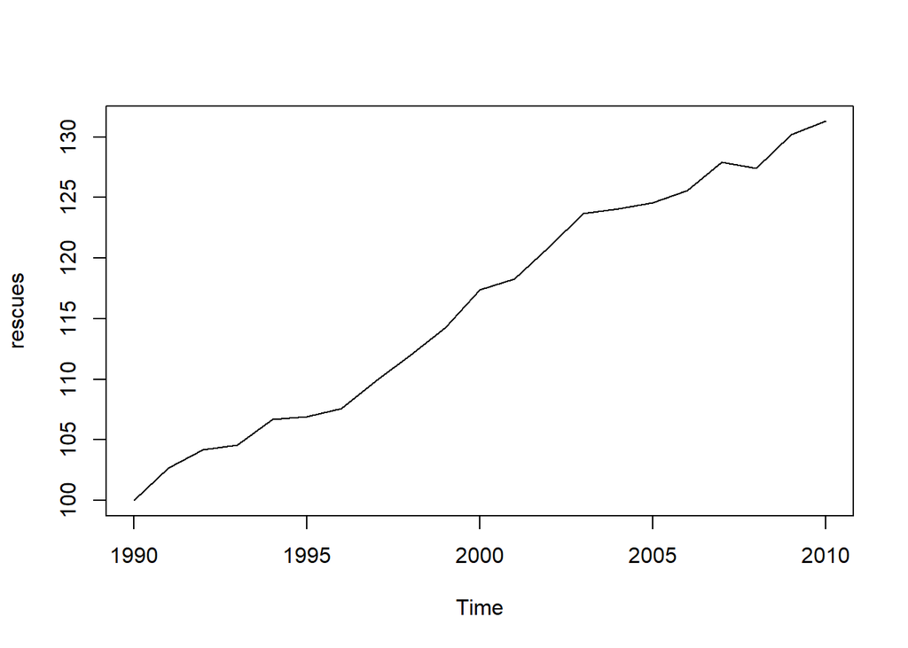

```r
rescues <- ts(c(100.0, 102.7, 104.2, 104.6, 106.7,
106.9, 107.6, 109.9, 112.0, 114.3,
117.4, 118.3, 120.9, 123.7, 124.1,
124.6, 125.6, 127.9, 127.4, 130.2,
131.3), start=1990, freq=1)

plot(rescues)
```

There is a clear trend, which is close to linear, thus the simple approach should work well here. Taking first-order differences with lag 1 shows the yearly changes in the rescues. In R, the job is done with function diff().

```r
diff(rescues)
```

```
## Time Series:
## Start = 1991
## End = 2010
## Frequency = 1
##  [1]  2.7  1.5  0.4  2.1  0.2  0.7  2.3  2.1  2.3  3.1  0.9  2.6  2.8  0.4  0.5
## [16]  1.0  2.3 -0.5  2.8  1.1
```

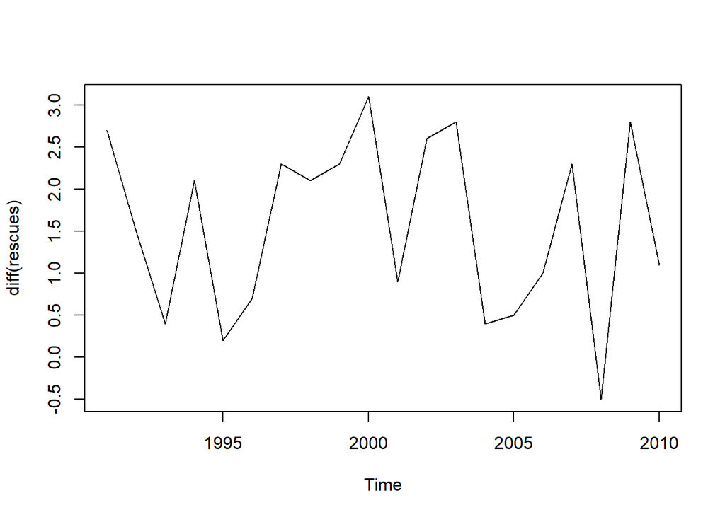

```r
plot.ts(diff(rescues))
```